# Chapter 4 - Distributions of Random Variables

JOe Rovalino

**Area under the curve, Part I**. (4.1, p. 142) What percent of a standard normal distribution $N(\mu=0, \sigma=1)$ is found in each region? Be sure to draw a graph.

```r
library(DATA606)
```

```r
library(ggplot2)
```

1. $Z < -1.35$

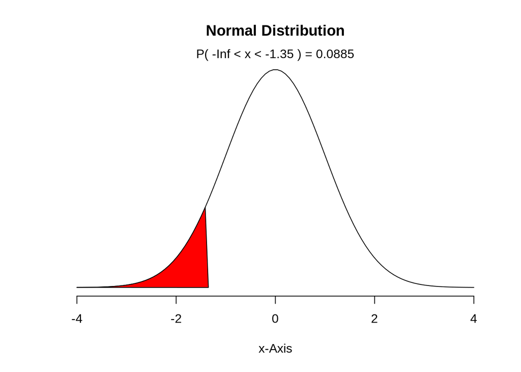

```r
normalPlot(bounds = c(-Inf,-1.35))
```

```r
pnorm(-1.35)
```

```
## [1] 0.08850799
```

8.86 % of area

2. $Z > 1.48$

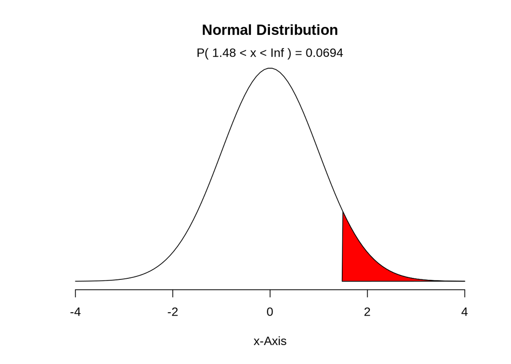

```r
normalPlot(bounds = c(1.48,Inf))
```

```r
1-pnorm(1.48)
```

```
## [1] 0.06943662
```

6.95 % of area

3. $-0.4 < Z < 1.5$

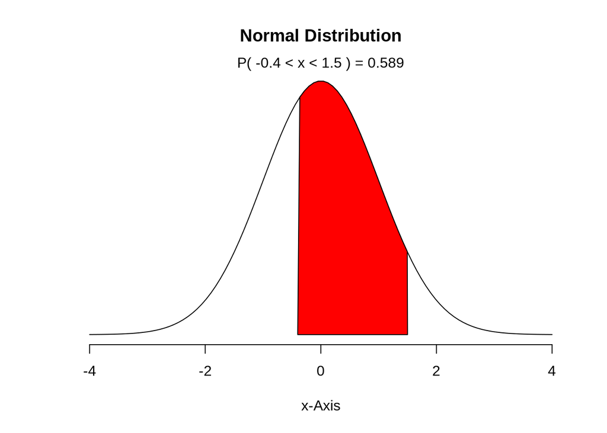

```r
normalPlot(bounds = c(-0.4,1.5))
```

```r
pnorm(1.5)-pnorm(-0.4)
```

```
## [1] 0.5886145
```

58.9 % of area (d) $|Z| > 2$

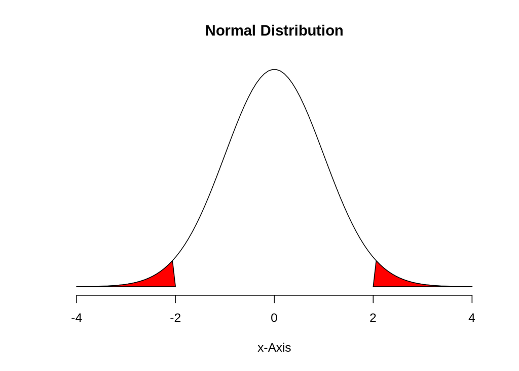

```r
normalPlot(bounds = c(-2,2), tails = TRUE)
```

```r
pnorm(-2)*2
```

```
## [1] 0.04550026
```

4.55 % of aea

**Triathlon times, Part I** (4.4, p. 142) In triathlons, it is common for racers to be placed into age and gender groups. Friends Leo and Mary both completed the Hermosa Beach Triathlon, where Leo competed in the *Men, Ages 30 - 34* group while Mary competed in the *Women, Ages 25 - 29* group. Leo completed the race in 1:22:28 (4948 seconds), while Mary completed the race in 1:31:53 (5513 seconds). Obviously Leo finished faster, but they are curious about how they did within their respective groups. Can you help them? Here is some information on the performance of their groups:

- The finishing times of the group has a mean of 4313 seconds with a standard deviation of 583 seconds.
- The finishing times of the group has a mean of 5261 seconds with a standard deviation of 807 seconds.
- The distributions of finishing times for both groups are approximately Normal.

Remember: a better performance corresponds to a faster finish.

Men, Ages 30 - 34: N(μ=4313,σ=583) Women, Ages 25 - 29: N(μ=5261,σ=807)

2. What are the Z-scores for Leo’s and Mary’s finishing times? What do these Z-scores tell you?

```r
mean_m <- 4313
sd_m <-583
mean_w <- 5261
sd_w <-807
z_leo <-(4948-mean_m)/sd_m
z_leo
```

```
## [1] 1.089194
```

```r
z_mary<-(5513-mean_w)/sd_w
z_mary
```

```
## [1] 0.3122677
```

JR Answer: Leo’s Z score is 1.089194 Mary’s Z score is 0.3122677 Leo is 1.089 SD longer then average Mary is 0.312 SD longer then average

```r
MRank <-pnorm(z_mary)
MRank
```

```
## [1] 0.6225814
```

```r
LRank <- pnorm(z_leo)
LRank
```

```
## [1] 0.8619658
```

4. What percent of the triathletes did Leo finish faster than in his group?

0.8619658

5. What percent of the triathletes did Mary finish faster than in her group?

0.6225814

6. If the distributions of finishing times are not nearly normal, would your answers to parts (b) - (e) change? Explain your reasoning.

**Heights of female college students** Below are heights of 25 female college students.

$$\stackrel{1}{54}, \stackrel{2}{55}, \stackrel{3}{56}, \stackrel{4}{56},
\stackrel{5}{57}, \stackrel{6}{58}, \stackrel{7}{58}, \stackrel{8}{59},
\stackrel{9}{60}, \stackrel{10}{60}, \stackrel{11}{60}, \stackrel{12}{61},
\stackrel{13}{61}, \stackrel{14}{62}, \stackrel{15}{62}, \stackrel{16}{63},
\stackrel{17}{63}, \stackrel{18}{63}, \stackrel{19}{64}, \stackrel{20}{65},
\stackrel{21}{65}, \stackrel{22}{67}, \stackrel{23}{67}, \stackrel{24}{69},
\stackrel{25}{73}$$

1. The mean height is 61.52 inches with a standard deviation of 4.58 inches. Use this information to determine if the heights approximately follow the 68-95-99.7% Rule.

```r
fheight <- c(54, 55, 56, 56, 57, 58, 58, 59, 60, 60, 60, 61, 61, 62, 62, 63, 63, 63, 64, 65, 65, 67, 67, 69, 73)
summary(fheight)
```

```
##    Min. 1st Qu.  Median    Mean 3rd Qu.    Max.
##   54.00   58.00   61.00   61.52   64.00   73.00
```

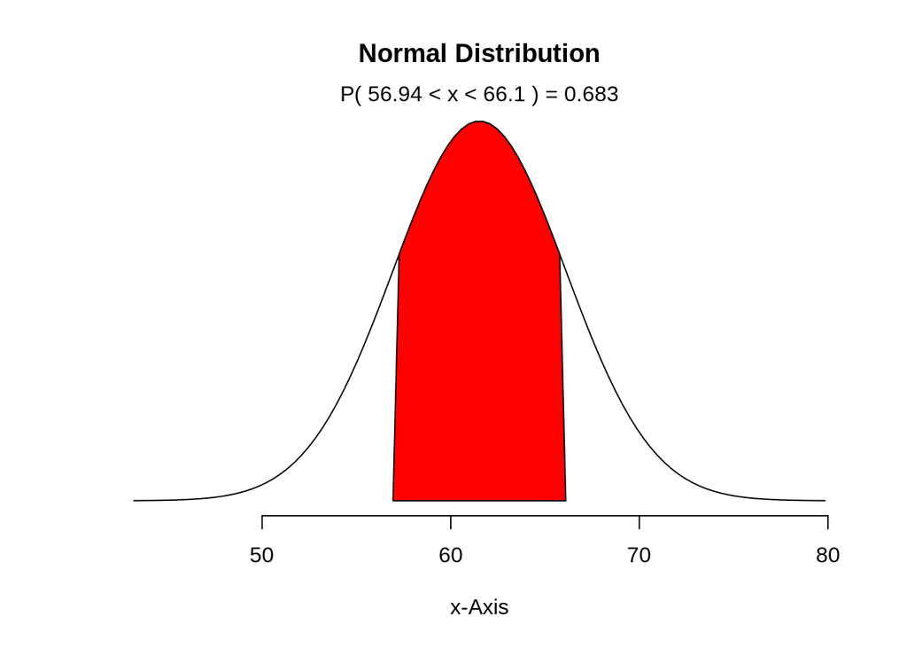

```r
mean_fheight <- 61.52
sd_fheight <- 4.58
#68 view
normalPlot(mean = 61.52, sd = 4.58, bounds = c((mean_fheight-sd_fheight), (mean_fheight+sd_fheight)), tails = FALSE)
```

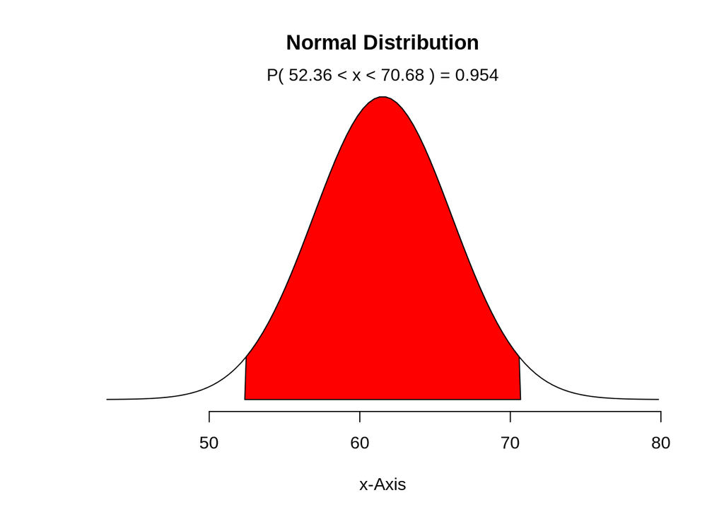

```r
#95 view
normalPlot(mean = 61.52, sd = 4.58, bounds = c((mean_fheight-2*sd_fheight), (mean_fheight+ 2*sd_fheight)), tails = FALSE)
```

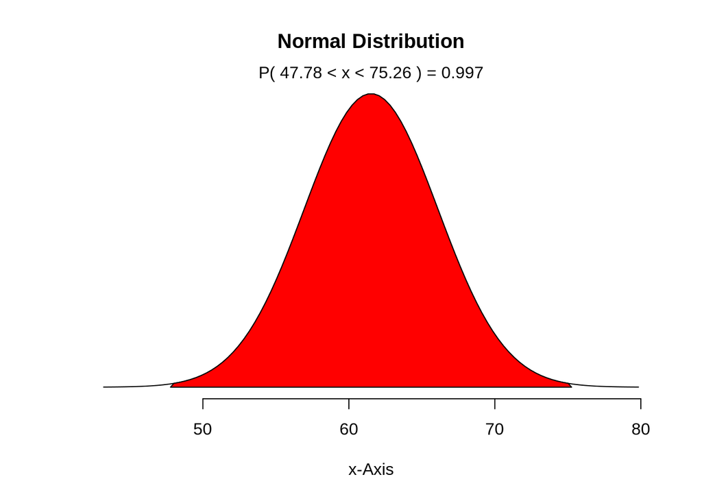

```r
# 99.7 view
normalPlot(mean = 61.52, sd = 4.58, bounds = c((mean_fheight-3*sd_fheight), (mean_fheight+3*sd_fheight)), tails = FALSE)
```

JR Answer: They do follow the heights approximately according to the 68-95-99.7 rule

2. Do these data appear to follow a normal distribution? Explain your reasoning using the graphs provided below.

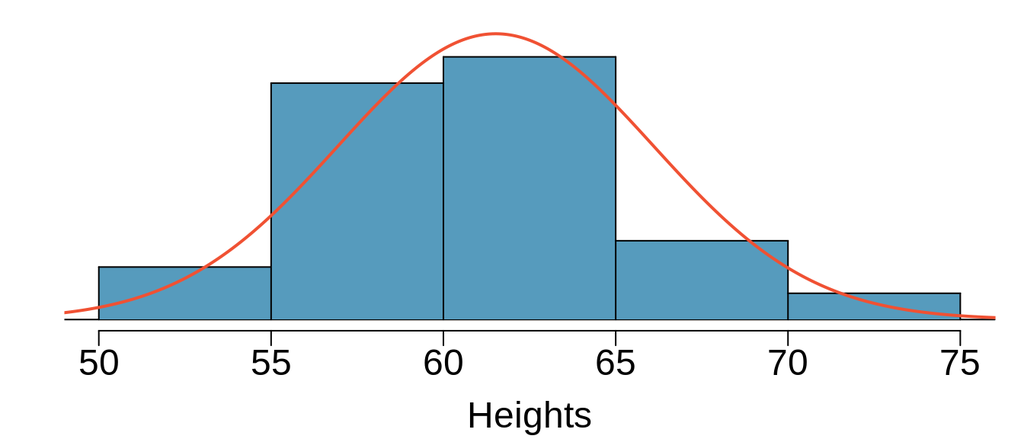

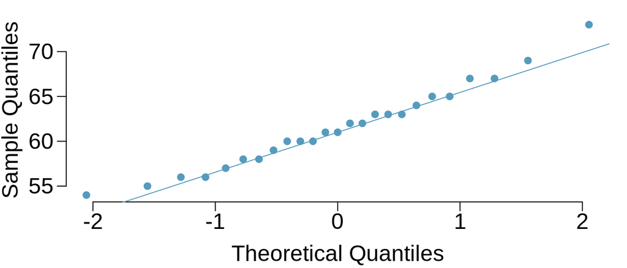

Answer: It does follow a normal distribution but for the skewness in the tails - especially the rigth skew as clearly seen in the qq plot (right side)

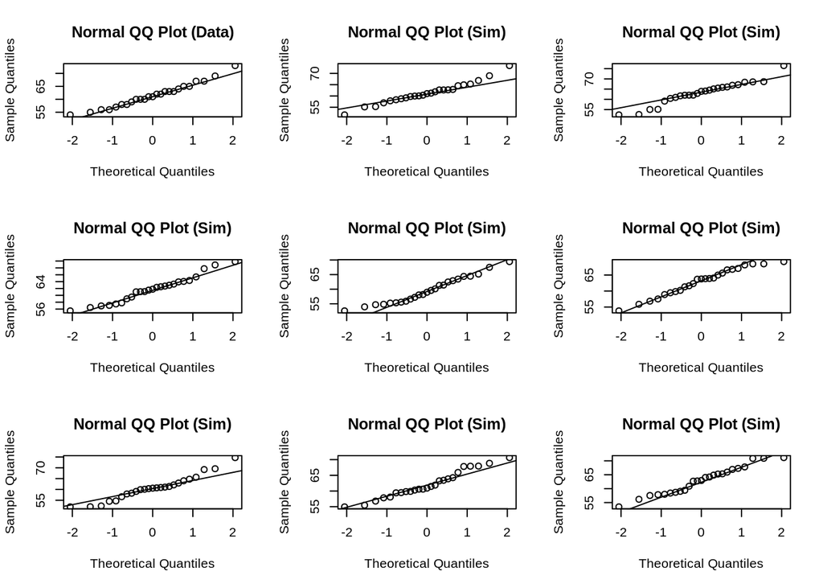

```r
# Use the DATA606::qqnormsim function

qqnormsim(fheight)
```

**Defective rate.** (4.14, p. 148) A machine that produces a special type of transistor (a component of computers) has a 2% defective rate. The production is considered a random process where each transistor is independent of the others.

1. What is the probability that the 10th transistor produced is the first with a defect?

```r
defct<- 0.98*0.98*0.98*0.98*0.98*0.98*0.98*0.98*0.98*0.02
defct
```

```
## [1] 0.01667496
```

JR Answer; 0.01667496 chance of a defect in first 10.

2. What is the probability that the machine produces no defective transistors in a batch of 100?

```r
nodefct <- .98^100
nodefct
```

```
## [1] 0.1326196
```

JR Answer: 0.1326196 probabiity of no defectin 100

3. On average, how many transistors would you expect to be produced before the first with a defect? What is the standard deviation?

```r
mean <- 1/.02
mean
```

```
## [1] 50
```

```r
sd <- sqrt((1-.02)/(0.02)^2)
sd
```

```
## [1] 49.49747
```

JR Answer: Expect to get a defect after 50 produced transistors. The SD is 49.49747

4. Another machine that also produces transistors has a 5% defective rate where each transistor is produced independent of the others. On average how many transistors would you expect to be produced with this machine before the first with a defect? What is the standard deviation?

```r
mean2 <- 1/.05
mean2
```

```
## [1] 20
```

```r
sd <- sqrt((1-.05)/(0.05)^2)
sd
```

```
## [1] 19.49359
```

JR Answer: This second machine should produce a defect at 20 transistors.

5. Based on your answers to parts (c) and (d), how does increasing the probability of an event affect the mean and standard deviation of the wait time until success?

JR Answer: The increase in the probability of defect caused a decrese in mean and SD.

**Male children.** While it is often assumed that the probabilities of having a boy or a girl are the same, the actual probability of having a boy is slightly higher at 0.51. Suppose a couple plans to have 3 kids.

1. Use the binomial model to calculate the probability that two of them will be boys.

```r
prob2boys <- dbinom(2,3,0.51)
prob2boys
```

```
## [1] 0.382347
```

JR Answer: 0.382347 is the prob of having 2 boys

2. Write out all possible orderings of 3 children, 2 of whom are boys. Use these scenarios to calculate the same probability from part (a) but using the addition rule for disjoint outcomes. Confirm that your answers from parts (a) and (b) match.
3. If we wanted to calculate the probability that a couple who plans to have 8 kids will have 3 boys, briefly describe why the approach from part (b) would be more tedious than the approach from part (a).

**Serving in volleyball.** (4.30, p. 162) A not-so-skilled volleyball player has a 15% chance of making the serve, which involves hitting the ball so it passes over the net on a trajectory such that it will land in the opposing team’s court. Suppose that her serves are independent of each other.

1. What is the probability that on the 10th try she will make her 3rd successful serve?
2. Suppose she has made two successful serves in nine attempts. What is the probability that her 10th serve will be successful?
3. Even though parts (a) and (b) discuss the same scenario, the probabilities you calculated should be different. Can you explain the reason for this discrepancy?